# Bayesian Data Analysis: HW3

Devin Jones dj2374

September 30, 2015

## Part 1

Suppose $y_{1},...,y_{5}$ are indpendent samples from a Cauchy distribution with unknown center $\theta$ and known scale 1. That is, $p(y_{i} | \theta) \propto \frac{1}{1 + (y_{i} - \theta)^{2}}$. Assume the prior distribution on $\theta$ is uniform on [0,1] and the observations on $y$ are (-2,-1,0,1.5,2.5).

### A. Plot the posterior density

The posterior density of $\theta$ follows $p( \theta | y) \propto p(y | \theta) p(\theta)$, where $p(\theta)=\frac{1}{1-0}=1$. Therefore, the posterior is proportional to the Cauchy distribution over the interval [0,1]. The density is shown in the visualization below.

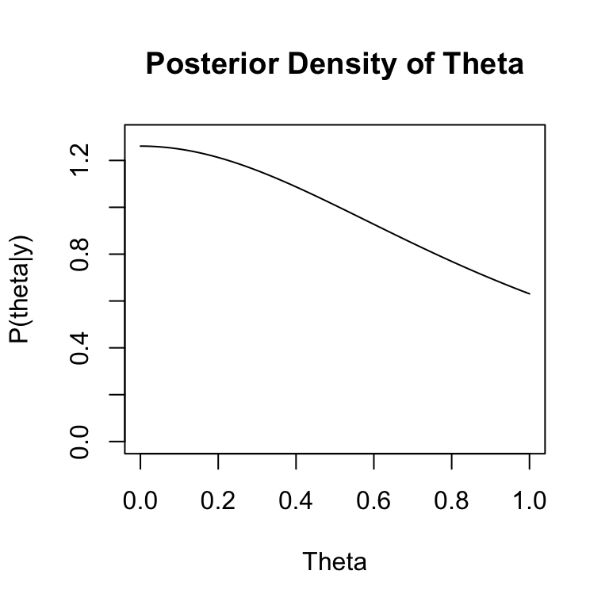

### B. Determine the derivative and the second derivate of the log posterior density

Posterior: $p( \theta | y) \propto \frac{1}{1 + (y_{i} - \theta)^{2}}$

First derivative of log posterior: $\frac{\partial l}{\partial \theta} = \frac{2(y_{i} - \theta)}{1 - (y_{i} - \theta)^{2}}$

Using the quotient rule for derivatives, the second derivative of log posterior: $\frac{\partial ^{2} l}{\partial \theta^{2}} = \frac{-2(1- (y_{i} - \theta)^{2}) -4(y_{i} - \theta)(y_{i} - \theta)}{(1-(y_{i}-\theta)^{2})^{2}}$

$\Rightarrow \frac{-2+ 2(y_{i} - \theta)^{2} -4(y_{i} - \theta)^{2}}{(1-(y_{i}-\theta)^{2})^{2}}$ $\Rightarrow \frac{2(1 - (y_{i} - \theta)^{2})}{(1-(y_{i}-\theta)^{2})^{2}}$

which can be reduced to $\frac{\partial ^{2} l}{\partial \theta^{2}} = \frac{2}{1-(y_{i}-\theta)^{2})}$

## Part 2

### A. Fit a model in Stan to estimate the effect of electromagnetic fields at different frequencies on calcium ions released from chicken brains. This question is of scientific interest, because if there is an effect, then it suggests that low-frequency electromagnetic fields can affect brain functioning.

The data is described in more detail in the assignment, but in summary consists of two sets of mean ratios, standard errors, and sample sizes fore each observation of calcium ions released after exposure to a given frequency level. One of these sets of summary statistics is the ratio of an exposed observation to control, and the other is the ratio of a ‘sham’.

To measure the effect of the treatment, both sets of observations can be parameterized seperately and compared after simulation. At first, the ratio effect of each group over each frequencies was considered to have a $student t(\eta,\sigma)$ distribution with degrees of freedome equal to the sample size. A prior distribution was placed on $\eta$ over all frequencies following $N(\mu,\sigma)$ where $\mu$ and $\sigma$ are unknown.

### C. What is the role of the “sham” treatment? Why is it performed at all?

The sham treatment in this data is a bit confusing, however it seems this part of the experiment is useful in at least one sense. Namely, the data shows that the mean sham ratio not centered on zero, suggesting placing half of the brain in the chamber with no electronic treatment influences the ion emission compared placing the brain in water. This evidence could suggest that the control group (placing the brain in water) is not a reasonable baseline to compare against the exposed group, or that there are other variables in the experiment that are not accounted for such as remnant electronic frequencies from previous experiments or other instruments.